# Week 09: Mailer Benefits

Alison

2025-03-13

We will use the full mailing.csv set from your assignment.

```r
load('./mailing_expected_benefit.rda')
mailing_xgb <- xgb.load('./mailing_response_model.xgb')
```

# Expected Benefit

- Individual-level profitability based on predicted probabilities.
- Helps determine precisely who to mail.

Expected benefit of targeting somebody - we will look now at the probability of responding given all the data (p(R|x)):

Create $P(R|\textbf{x})$

```r
o <- mailing %>%
    dplyr::select(all_of(colnames(mailing_xs_train))) %>%
    as.matrix()

mailing$prob_response <- predict(mailing_xgb, newdata = o)

# look at highest probability of donating
max(mailing$prob_response)
```

```
## [1] 0.228673
```

How much they donate: v(x)

The value of a response, $v_R(\textbf{x})$, is equal to `gavr`, the average gift size that they do give.

We’ll set the mailing cost to £1

```r
#cost is £1 to post a request (what other costs are involved?)
mailing_cost <- 1

#gavr is average donation
mailing <- mailing %>%
  mutate(response_value = gavr - mailing_cost) %>%
  mutate(expected_benefit = prob_response * response_value) %>%
  arrange(desc(expected_benefit))

#total possible amount of net benefit if everyone is targeted.
# Positive total indicates the campaign as a whole is financially beneficial.
sum(mailing$expected_benefit)
```

```
## [1] 105189
```

```r
#how many below 0?
mailing %>% filter(expected_benefit < 0)
```

```
## # A tibble: 0 × 21
## # ℹ 21 variables: Income <dbl>, Firstdate <dbl>, Lastdate <dbl>, Amount <dbl>,
## #   glast <dbl>, gavr <dbl>, class <fct>, rfaf2_1 <int>, rfaf2_4 <int>,
## #   rfaf2_2 <int>, rfaf2_3 <int>, rfaa2_G <int>, rfaa2_E <int>, rfaa2_F <int>,
## #   rfaa2_D <int>, pepstrfl_0 <int>, pepstrfl_X <int>, cv_part <int>,
## #   prob_response <dbl>, response_value <dbl>, expected_benefit <dbl>
```

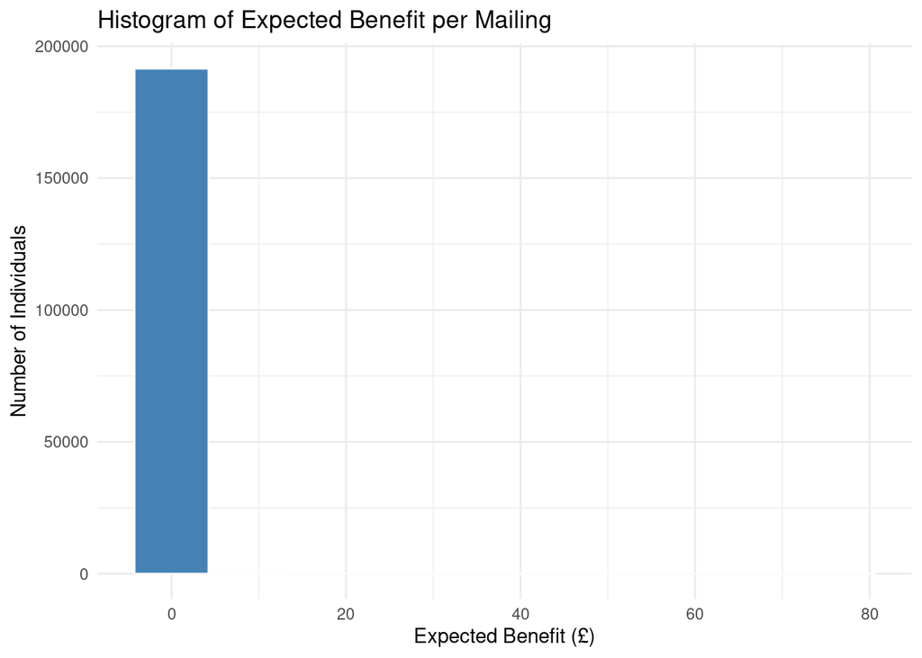

```r
#plot histogram of expected benefit
ggplot(mailing, aes(x = expected_benefit)) +
  geom_histogram(bins = 10, fill = "steelblue", color = "white") +
  labs(title = "Histogram of Expected Benefit per Mailing",
       x = "Expected Benefit (£)",
       y = "Number of Individuals") +
  theme_minimal()
```

There’s a net benefit to reaching to everyone.

But what if costs increase? For some it’s no longer worth targetting them.

```r
mailing_cost <- 2

mailing_cost_change <- mailing %>%
  mutate(response_value = gavr - mailing_cost) %>%
  mutate(expected_benefit = prob_response * response_value) #%>%

# negative benefit count - the number of people it is not profitable to target
sum(mailing_cost_change$expected_benefit < 0)
```

```
## [1] 36
```

```r
#total possible amount of net benefit if we target everyone
sum(mailing_cost_change$expected_benefit)
```

```
## [1] 95445.62
```

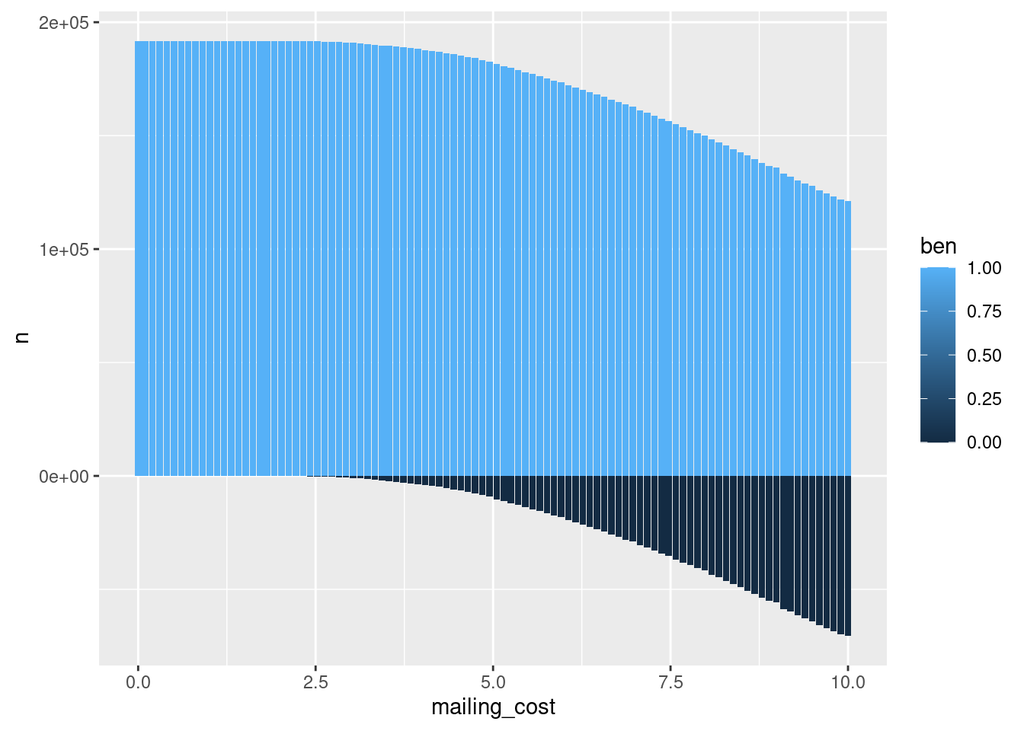

```r
mailing_benefit <- function(mailing_cost = 1) {
  o <- mailing %>%
    dplyr::mutate(response_value = gavr - mailing_cost) %>%               #response value
    dplyr::mutate(expected_benefit = prob_response * response_value) %>%  #expected beneift
    dplyr::mutate(ben = ifelse(expected_benefit < 0, 0, 1)) %>%           #binary change point
    dplyr::count(ben) %>%                                                 #no benefit/benefit counts (count 1s and 0s)
    dplyr::mutate(mailing_cost = mailing_cost)                            #mailing_cost may change as argument in function
  return(o)
}

i <- seq(0, 10, length.out = 100)                                         #apply for mailing costs 0-10 (increments up to 100)

d <- lapply(i, mailing_benefit) %>%
  bind_rows() %>%                                                         #  bind into a single dataset
  mutate(n = ifelse(ben == 0, -n, n))

ggplot(d, aes(x = mailing_cost, y = n, fill = ben)) +
  geom_col()
```

# Profit Curves

- Uses actual outcomes (confusion matrices) at different probability thresholds.
- Helps determine the optimal overall mailing strategy (**at which threshold to mail**), balancing false positives (wasted mail costs) and false negatives (missed donations).

Let’s say that our profit margin is small: each offer costs £1 to make and market, and each accepted offer earns £18, for a profit of £17. We can produce a profit matrix where if we send a postcard, and they respond we get £17, and if we send a post-card and they fail to respond we lose the £1 we invested. And if we send nothing, we get nothing and lose nothing.

False positive - we thought they’d donate, but they didn’t.  
False negative - we thought they wouldn’t donate, but they would have

```r
# should P-Ignored / Donated be -17? I think it should.

prof_matrix <- matrix(c(0, 0, -1, 17), byrow = T, nrow=2,
                      dimnames = list(c("P-Ignored", "P-Donated"), c("Ignored", "Donated")))
prof_matrix
```

```
##           Ignored Donated
## P-Ignored       0       0
## P-Donated      -1      17
```

We can change the thresholds using our mailing data using the XGBoost model OUr cost matrix assigns values to a FP, FN, TP, TN

```r
p_thresh <- 0.50
the_model_results <- factor(ifelse(mailing$prob_response > p_thresh, 1, 0), levels = c(0, 1))
the_actual_data <- mailing$class
cm_50 <- caret::confusionMatrix(the_model_results, the_actual_data)

p_thresh <- 0.05
the_model_results <- factor(ifelse(mailing$prob_response > p_thresh, 1, 0), levels = c(0, 1))
the_actual_data <- mailing$class
cm_05 <- caret::confusionMatrix(the_model_results, the_actual_data)

cm_50$table
```

```
##           Reference
## Prediction      0      1
##          0 182063   9716
##          1      0      0
```

```r
cm_05$table
```

```
##           Reference
## Prediction      0      1
##          0 109162   4010
##          1  72901   5706
```

Average profit per person at the 5% threshold is $0.13 / person, if we use the values defined

```r
n_cases <- nrow(mailing)
sum((cm_05$table/n_cases) * prof_matrix)
```

```
## [1] 0.1256707
```

At the 50% threshold, we just don’t send anything. Should we have an opportunity cost though, as we lost £17 with our false negatives!?

```r
n_cases <- nrow(mailing)
sum((cm_50$table/n_cases) * prof_matrix)
```

```
## [1] 0
```

Write a function that will compute this for any threshold (total profit):

```r
prof_threshold <- function(p_thresh, prof_matrix) {
  the_model_results <- factor(ifelse(mailing$prob_response > p_thresh, 1, 0),
                              levels = c(0, 1))
  the_actual_data <- mailing$class
  cm <- caret::confusionMatrix(the_model_results, the_actual_data)
  sum(cm$table * prof_matrix)
}
prof_threshold(0.05, prof_matrix)
```

```
## [1] 24101
```

Plot to visualize and quantify the trade-offs between taking different actions based on our predictive model

```r
i <- seq(0,0.5, length.out = 100)
profits <- sapply(i, prof_threshold, prof_matrix = prof_matrix)
d <- tibble(i, profits)
```

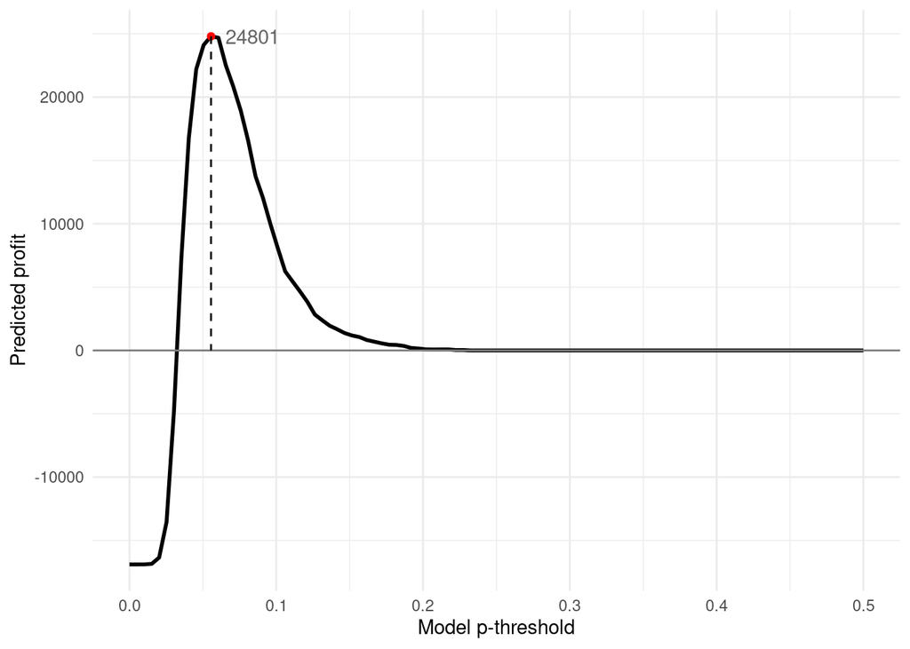

```r
max_prof <- which.max(d$profits)

ggplot(d, aes(x = i, y = profits)) +
  geom_line(linewidth = 1) +
  geom_hline(yintercept = 0, color = 'grey50') +
  theme_minimal() +
  annotate(geom = "point", color = 'red',
           x = d$i[max_prof], y = d$profits[max_prof]) +
  annotate(geom = "text", color = 'grey40',
           x = d$i[max_prof] + 0.01, y = d$profits[max_prof],  label = d$profits[max_prof],
           hjust = "left") +
  annotate(geom = "segment", x = d$i[max_prof], y = d$profits[max_prof],
           xend = d$i[max_prof], yend = 0, linetype = 2) +
  xlab("Model p-threshold") +
  ylab("Predicted profit")
```

What if we included opportunity costs? If we don’t target someone who would have donated it is a cost to us.

```r
prof_matrix2 <- matrix(c(0, -17, -1, 17), byrow = T, nrow=2,
                      dimnames = list(c("P-Ignored", "P-Donated"), c("Ignored", "Donated")))
prof_matrix2
```

```
##           Ignored Donated
## P-Ignored       0     -17
## P-Donated      -1      17
```

```r
d$profits2 <- sapply(i, prof_threshold, prof_matrix = prof_matrix2)
```

Opportunity cost maybe isn’t the best way to model this. So we need better data - so we can include opportunity cost. It seems the data isn’t sufficient to target people.

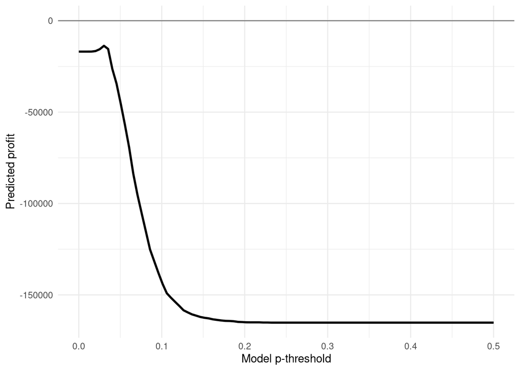

```r
ggplot(d, aes(x = i, y = profits2)) +
  geom_line(linewidth = 1) +
  geom_hline(yintercept = 0, color = 'grey50') +
  theme_minimal() +
  xlab("Model p-threshold") +
  ylab("Predicted profit")
```